# Machine Learning Data Exploration

Riddhi Sharma

2022-12-05

#R Markdown

#Reading the Data:

```r
library(tidyverse)
rm(list=ls())

airline_data <- read.csv("./AirlineCustomerSatisfaction.csv", header=T, stringsAsFactors=T)

summary(airline_data)
```

```
##        satisfaction      Gender                Customer.Type         Age
##  dissatisfied:58793   Female:65899   disloyal Customer: 23780   Min.   : 7.00
##  satisfied   :71087   Male  :63981   Loyal Customer   :106100   1st Qu.:27.00
##                                                                 Median :40.00
##                                                                 Mean   :39.43
##                                                                 3rd Qu.:51.00
##                                                                 Max.   :85.00
##
##          Type.of.Travel       Class       Flight.Distance  Seat.comfort
##  Business travel:89693   Business:62160   Min.   :  50    Min.   :0.000
##  Personal Travel:40187   Eco     :58309   1st Qu.:1359    1st Qu.:2.000
##                          Eco Plus: 9411   Median :1925    Median :3.000
##                                           Mean   :1981    Mean   :2.839
##                                           3rd Qu.:2544    3rd Qu.:4.000
##                                           Max.   :6951    Max.   :5.000
##
##  Departure.Arrival.time.convenient Food.and.drink  Gate.location
##  Min.   :0.000                     Min.   :0.000   Min.   :0.00
##  1st Qu.:2.000                     1st Qu.:2.000   1st Qu.:2.00
##  Median :3.000                     Median :3.000   Median :3.00
##  Mean   :2.991                     Mean   :2.852   Mean   :2.99
##  3rd Qu.:4.000                     3rd Qu.:4.000   3rd Qu.:4.00
##  Max.   :5.000                     Max.   :5.000   Max.   :5.00
##
##  Inflight.wifi.service Inflight.entertainment Online.support
##  Min.   :0.000         Min.   :0.000          Min.   :0.00
##  1st Qu.:2.000         1st Qu.:2.000          1st Qu.:3.00
##  Median :3.000         Median :4.000          Median :4.00
##  Mean   :3.249         Mean   :3.383          Mean   :3.52
##  3rd Qu.:4.000         3rd Qu.:4.000          3rd Qu.:5.00
##  Max.   :5.000         Max.   :5.000          Max.   :5.00
##
##  Ease.of.Online.booking On.board.service Leg.room.service Baggage.handling
##  Min.   :0.000          Min.   :0.000    Min.   :0.000    Min.   :1.000
##  1st Qu.:2.000          1st Qu.:3.000    1st Qu.:2.000    1st Qu.:3.000
##  Median :4.000          Median :4.000    Median :4.000    Median :4.000
##  Mean   :3.472          Mean   :3.465    Mean   :3.486    Mean   :3.696
##  3rd Qu.:5.000          3rd Qu.:4.000    3rd Qu.:5.000    3rd Qu.:5.000
##  Max.   :5.000          Max.   :5.000    Max.   :5.000    Max.   :5.000
##
##  Checkin.service  Cleanliness    Online.boarding Departure.Delay.in.Minutes
##  Min.   :0.000   Min.   :0.000   Min.   :0.000   Min.   :   0.00
##  1st Qu.:3.000   1st Qu.:3.000   1st Qu.:2.000   1st Qu.:   0.00
##  Median :3.000   Median :4.000   Median :4.000   Median :   0.00
##  Mean   :3.341   Mean   :3.706   Mean   :3.353   Mean   :  14.71
##  3rd Qu.:4.000   3rd Qu.:5.000   3rd Qu.:4.000   3rd Qu.:  12.00
##  Max.   :5.000   Max.   :5.000   Max.   :5.000   Max.   :1592.00
##
##  Arrival.Delay.in.Minutes
##  Min.   :   0.00
##  1st Qu.:   0.00
##  Median :   0.00
##  Mean   :  15.09
##  3rd Qu.:  13.00
##  Max.   :1584.00
##  NA's   :393
```

#Logistics Regression Model

Reasons to us the Logistic Regression Model:

1. Generally easier to understand and interpret these models.
2. The model is faster to train than other models.
3. They can work well in scenerios in which the fit is not the best.

```r
summary(as.factor(airline_data$satisfaction))
```

```
## dissatisfied    satisfied
##        58793        71087
```

#Fitting a logistic regression model

```r
fit_1 <- glm(satisfaction ~.,
             family=binomial(link='logit'),
             data= airline_data)
summary(fit_1)
```

```
##
## Call:
## glm(formula = satisfaction ~ ., family = binomial(link = "logit"),
##     data = airline_data)
##
## Deviance Residuals:
##     Min       1Q   Median       3Q      Max
## -2.9849  -0.5774   0.1931   0.5193   3.6387
##
## Coefficients:
##                                     Estimate Std. Error  z value Pr(>|z|)
## (Intercept)                       -6.795e+00  6.540e-02 -103.898  < 2e-16 ***
## GenderMale                        -9.637e-01  1.647e-02  -58.520  < 2e-16 ***
## Customer.TypeLoyal Customer        1.978e+00  2.502e-02   79.050  < 2e-16 ***
## Age                               -7.741e-03  5.720e-04  -13.533  < 2e-16 ***
## Type.of.TravelPersonal Travel     -7.793e-01  2.344e-02  -33.251  < 2e-16 ***
## ClassEco                          -7.306e-01  2.123e-02  -34.415  < 2e-16 ***
## ClassEco Plus                     -8.077e-01  3.264e-02  -24.750  < 2e-16 ***
## Flight.Distance                   -1.107e-04  8.611e-06  -12.852  < 2e-16 ***
## Seat.comfort                       2.898e-01  9.213e-03   31.451  < 2e-16 ***
## Departure.Arrival.time.convenient -1.969e-01  6.781e-03  -29.038  < 2e-16 ***
## Food.and.drink                    -2.196e-01  9.363e-03  -23.458  < 2e-16 ***
## Gate.location                      1.146e-01  7.650e-03   14.979  < 2e-16 ***
## Inflight.wifi.service             -7.231e-02  8.890e-03   -8.134 4.14e-16 ***
## Inflight.entertainment             6.864e-01  8.308e-03   82.617  < 2e-16 ***
## Online.support                     9.090e-02  9.031e-03   10.065  < 2e-16 ***
## Ease.of.Online.booking             2.228e-01  1.163e-02   19.149  < 2e-16 ***
## On.board.service                   3.090e-01  8.252e-03   37.444  < 2e-16 ***
## Leg.room.service                   2.241e-01  7.021e-03   31.920  < 2e-16 ***
## Baggage.handling                   1.070e-01  9.297e-03   11.512  < 2e-16 ***
## Checkin.service                    2.961e-01  6.941e-03   42.655  < 2e-16 ***
## Cleanliness                        7.940e-02  9.670e-03    8.211  < 2e-16 ***
## Online.boarding                    1.716e-01  9.962e-03   17.222  < 2e-16 ***
## Departure.Delay.in.Minutes         3.287e-03  8.071e-04    4.072 4.65e-05 ***
## Arrival.Delay.in.Minutes          -8.543e-03  7.953e-04  -10.743  < 2e-16 ***
## ---
## Signif. codes:  0 '***' 0.001 '**' 0.01 '*' 0.05 '.' 0.1 ' ' 1
##
## (Dispersion parameter for binomial family taken to be 1)
##
##     Null deviance: 178341  on 129486  degrees of freedom
## Residual deviance:  99688  on 129463  degrees of freedom
##   (393 observations deleted due to missingness)
## AIC: 99736
##
## Number of Fisher Scoring iterations: 5
```

All the variables in the model are significant.

```r
fit_2<- glm(Customer.Type ~.,
             family=binomial(link='logit'),
             data= airline_data)
summary(fit_2)
```

```
##
## Call:
## glm(formula = Customer.Type ~ ., family = binomial(link = "logit"),
##     data = airline_data)
##
## Deviance Residuals:
##     Min       1Q   Median       3Q      Max
## -5.0523   0.0167   0.1322   0.3384   3.1361
##
## Coefficients:
##                                     Estimate Std. Error z value Pr(>|z|)
## (Intercept)                       -2.608e-01  8.368e-02  -3.116  0.00183 **
## satisfactionsatisfied              2.193e+00  2.844e-02  77.119  < 2e-16 ***
## GenderMale                         1.596e-01  2.088e-02   7.641 2.15e-14 ***
## Age                                8.003e-02  9.482e-04  84.392  < 2e-16 ***
## Type.of.TravelPersonal Travel      6.588e+00  7.887e-02  83.526  < 2e-16 ***
## ClassEco                          -1.341e+00  2.474e-02 -54.193  < 2e-16 ***
## ClassEco Plus                      4.572e-01  4.712e-02   9.703  < 2e-16 ***
## Flight.Distance                    2.877e-04  1.155e-05  24.922  < 2e-16 ***
## Seat.comfort                      -4.517e-01  1.262e-02 -35.798  < 2e-16 ***
## Departure.Arrival.time.convenient  3.383e-01  9.241e-03  36.611  < 2e-16 ***
## Food.and.drink                    -6.475e-02  1.211e-02  -5.346 9.00e-08 ***
## Gate.location                     -2.934e-02  1.040e-02  -2.822  0.00477 **
## Inflight.wifi.service             -2.184e-01  1.369e-02 -15.954  < 2e-16 ***
## Inflight.entertainment             4.316e-01  1.237e-02  34.883  < 2e-16 ***
## Online.support                     1.267e-01  1.290e-02   9.820  < 2e-16 ***
## Ease.of.Online.booking             6.016e-01  1.791e-02  33.586  < 2e-16 ***
## On.board.service                  -1.859e-01  9.874e-03 -18.825  < 2e-16 ***
## Leg.room.service                   1.519e-02  8.661e-03   1.754  0.07937 .
## Baggage.handling                  -3.451e-01  1.219e-02 -28.304  < 2e-16 ***
## Checkin.service                   -2.847e-01  9.064e-03 -31.406  < 2e-16 ***
## Cleanliness                       -3.383e-01  1.225e-02 -27.620  < 2e-16 ***
## Online.boarding                   -4.234e-01  1.630e-02 -25.980  < 2e-16 ***
## Departure.Delay.in.Minutes        -2.972e-03  1.023e-03  -2.904  0.00369 **
## Arrival.Delay.in.Minutes           4.168e-03  1.012e-03   4.118 3.83e-05 ***
## ---
## Signif. codes:  0 '***' 0.001 '**' 0.01 '*' 0.05 '.' 0.1 ' ' 1
##
## (Dispersion parameter for binomial family taken to be 1)
##
##     Null deviance: 123302  on 129486  degrees of freedom
## Residual deviance:  60865  on 129463  degrees of freedom
##   (393 observations deleted due to missingness)
## AIC: 60913
##
## Number of Fisher Scoring iterations: 8
```

#Significant Features

```r
t1 <- summary(fit_1)
t1$coefficients[t1$coefficients[,4] < 0.001,]
```

```
##                                        Estimate   Std. Error     z value
## (Intercept)                       -6.7947161292 6.539800e-02 -103.897926
## GenderMale                        -0.9637111284 1.646799e-02  -58.520266
## Customer.TypeLoyal Customer        1.9782142416 2.502482e-02   79.050088
## Age                               -0.0077405919 5.719771e-04  -13.533046
## Type.of.TravelPersonal Travel     -0.7792802392 2.343619e-02  -33.251144
## ClassEco                          -0.7305742961 2.122819e-02  -34.415286
## ClassEco Plus                     -0.8077456090 3.263661e-02  -24.749681
## Flight.Distance                   -0.0001106616 8.610718e-06  -12.851617
## Seat.comfort                       0.2897539927 9.212942e-03   31.450755
## Departure.Arrival.time.convenient -0.1968968713 6.780770e-03  -29.037539
## Food.and.drink                    -0.2196333316 9.362689e-03  -23.458360
## Gate.location                      0.1145946652 7.650163e-03   14.979375
## Inflight.wifi.service             -0.0723111388 8.889648e-03   -8.134308
## Inflight.entertainment             0.6864175710 8.308457e-03   82.616737
## Online.support                     0.0908970414 9.031316e-03   10.064651
## Ease.of.Online.booking             0.2227775367 1.163391e-02   19.148981
## On.board.service                   0.3089959295 8.252223e-03   37.443962
## Leg.room.service                   0.2240931100 7.020519e-03   31.919734
## Baggage.handling                   0.1070225032 9.296699e-03   11.511883
## Checkin.service                    0.2960542486 6.940614e-03   42.655338
## Cleanliness                        0.0794010399 9.670412e-03    8.210720
## Online.boarding                    0.1715669489 9.961800e-03   17.222485
## Departure.Delay.in.Minutes         0.0032868219 8.071111e-04    4.072329
## Arrival.Delay.in.Minutes          -0.0085432184 7.952686e-04  -10.742557
##                                        Pr(>|z|)
## (Intercept)                        0.000000e+00
## GenderMale                         0.000000e+00
## Customer.TypeLoyal Customer        0.000000e+00
## Age                                9.980141e-42
## Type.of.TravelPersonal Travel     1.965027e-242
## ClassEco                          1.489521e-259
## ClassEco Plus                     3.124934e-135
## Flight.Distance                    8.423117e-38
## Seat.comfort                      4.099017e-217
## Departure.Arrival.time.convenient 2.210758e-185
## Food.and.drink                    1.086161e-121
## Gate.location                      1.001542e-50
## Inflight.wifi.service              4.142975e-16
## Inflight.entertainment             0.000000e+00
## Online.support                     7.916775e-24
## Ease.of.Online.booking             9.869926e-82
## On.board.service                  7.531854e-307
## Leg.room.service                  1.421588e-223
## Baggage.handling                   1.149415e-30
## Checkin.service                    0.000000e+00
## Cleanliness                        2.198666e-16
## Online.boarding                    1.800882e-66
## Departure.Delay.in.Minutes         4.654536e-05
## Arrival.Delay.in.Minutes           6.424033e-27
```

```r
t2 <- summary(fit_2)
t2$coefficients[t1$coefficients[,4] < 0.001,]
```

```
##                                        Estimate   Std. Error    z value
## (Intercept)                       -0.2607676291 8.367884e-02  -3.116291
## satisfactionsatisfied              2.1929336575 2.843576e-02  77.118858
## GenderMale                         0.1595707349 2.088261e-02   7.641323
## Age                                0.0800251228 9.482519e-04  84.392266
## Type.of.TravelPersonal Travel      6.5877450631 7.887086e-02  83.525714
## ClassEco                          -1.3406054269 2.473775e-02 -54.192688
## ClassEco Plus                      0.4571583589 4.711749e-02   9.702519
## Flight.Distance                    0.0002877242 1.154516e-05  24.921625
## Seat.comfort                      -0.4517401417 1.261924e-02 -35.797731
## Departure.Arrival.time.convenient  0.3383256694 9.241101e-03  36.610969
## Food.and.drink                    -0.0647499830 1.211242e-02  -5.345753
## Gate.location                     -0.0293426586 1.039718e-02  -2.822175
## Inflight.wifi.service             -0.2183642191 1.368735e-02 -15.953724
## Inflight.entertainment             0.4316346688 1.237387e-02  34.882758
## Online.support                     0.1266914134 1.290096e-02   9.820306
## Ease.of.Online.booking             0.6015675765 1.791131e-02  33.585903
## On.board.service                  -0.1858765678 9.873735e-03 -18.825356
## Leg.room.service                   0.0151948804 8.661298e-03   1.754342
## Baggage.handling                  -0.3451175101 1.219328e-02 -28.303914
## Checkin.service                   -0.2846672118 9.064133e-03 -31.405895
## Cleanliness                       -0.3382997184 1.224832e-02 -27.620099
## Online.boarding                   -0.4233650473 1.629603e-02 -25.979642
## Departure.Delay.in.Minutes        -0.0029716182 1.023348e-03  -2.903820
## Arrival.Delay.in.Minutes           0.0041680303 1.012211e-03   4.117750
##                                        Pr(>|z|)
## (Intercept)                        1.831413e-03
## satisfactionsatisfied              0.000000e+00
## GenderMale                         2.150014e-14
## Age                                0.000000e+00
## Type.of.TravelPersonal Travel      0.000000e+00
## ClassEco                           0.000000e+00
## ClassEco Plus                      2.941461e-22
## Flight.Distance                   4.337662e-137
## Seat.comfort                      1.197944e-280
## Departure.Arrival.time.convenient 1.913651e-293
## Food.and.drink                     9.004189e-08
## Gate.location                      4.769910e-03
## Inflight.wifi.service              2.684020e-57
## Inflight.entertainment            1.357474e-266
## Online.support                     9.206394e-23
## Ease.of.Online.booking            2.694721e-247
## On.board.service                   4.680547e-79
## Leg.room.service                   7.937190e-02
## Baggage.handling                  3.093091e-176
## Checkin.service                   1.681130e-216
## Cleanliness                       6.383593e-168
## Online.boarding                   8.412335e-149
## Departure.Delay.in.Minutes         3.686404e-03
## Arrival.Delay.in.Minutes           3.825898e-05
```

#Categorical variables transformed into binary columns

#Now, data is ready to run models

```r
satisfied <- as.numeric(airline_data$satisfaction)
customer_type <- as.numeric(airline_data$Customer.Type)
```

```r
model_data <- fastDummies::dummy_cols(airline_data[,c(2,4:23)], select_columns = c("Gender", "Type.of.Travel", "Class"),
   remove_selected_columns = TRUE)

model_data$satisfied <- satisfied
model_data$customer_type <- customer_type
```

```r
library(splitstackshape)
set.seed(123456) # Set seed
# Perform stratified sampling
split_dat <- stratified(model_data, # Set dataset
                       group = c("satisfied", "customer_type"), # Set variables to use for stratification
                       size = 0.2,  # Set size of test set
                       bothSets = TRUE ) # Return both training and test sets
# Extract train data
train_dat <- split_dat[[2]]
# Extract test data
test_dat <- split_dat[[1]]
```

```r
names(train_dat)
```

```
##  [1] "Age"                               "Flight.Distance"
##  [3] "Seat.comfort"                      "Departure.Arrival.time.convenient"
##  [5] "Food.and.drink"                    "Gate.location"
##  [7] "Inflight.wifi.service"             "Inflight.entertainment"
##  [9] "Online.support"                    "Ease.of.Online.booking"
## [11] "On.board.service"                  "Leg.room.service"
## [13] "Baggage.handling"                  "Checkin.service"
## [15] "Cleanliness"                       "Online.boarding"
## [17] "Departure.Delay.in.Minutes"        "Arrival.Delay.in.Minutes"
## [19] "Gender_Female"                     "Gender_Male"
## [21] "Type.of.Travel_Business travel"    "Type.of.Travel_Personal Travel"
## [23] "Class_Business"                    "Class_Eco"
## [25] "Class_Eco Plus"                    "satisfied"
## [27] "customer_type"
```

```r
names(test_dat)
```

```
##  [1] "Age"                               "Flight.Distance"
##  [3] "Seat.comfort"                      "Departure.Arrival.time.convenient"
##  [5] "Food.and.drink"                    "Gate.location"
##  [7] "Inflight.wifi.service"             "Inflight.entertainment"
##  [9] "Online.support"                    "Ease.of.Online.booking"
## [11] "On.board.service"                  "Leg.room.service"
## [13] "Baggage.handling"                  "Checkin.service"
## [15] "Cleanliness"                       "Online.boarding"
## [17] "Departure.Delay.in.Minutes"        "Arrival.Delay.in.Minutes"
## [19] "Gender_Female"                     "Gender_Male"
## [21] "Type.of.Travel_Business travel"    "Type.of.Travel_Personal Travel"
## [23] "Class_Business"                    "Class_Eco"
## [25] "Class_Eco Plus"                    "satisfied"
## [27] "customer_type"
```

```r
sum(is.na(train_dat))
```

```
## [1] 316
```

```r
sum(is.na(test_dat))
```

```
## [1] 77
```

```r
nlevels(factor(train_dat$satisfied))
```

```
## [1] 2
```

```r
summary(factor(train_dat$satisfied))
```

```
##     1     2
## 47034 56870
```

```r
summary(factor(test_dat$satisfied))
```

```
##     1     2
## 11759 14217
```

```r
library(xgboost)
```

#### Satisfaction as response

```r
dtrain <- xgb.DMatrix(data = as.matrix(train_dat[, c(1:25, 27)]), label = as.numeric(train_dat$satisfied) - 1)
# Create test matrix
dtest <- xgb.DMatrix(data = as.matrix(test_dat[, c(1:25, 27)]), label = as.numeric(test_dat$satisfied) - 1)
```

```r
set.seed(111111)
bst_1 <- xgboost(data = dtrain, # Set training data

               nrounds = 100, # Set number of rounds

               verbose = 1, # 1 - Prints out fit
                print_every_n = 20, # Prints out result every 20th iteration

               objective = "binary:logistic", # Set objective
               eval_metric = "auc",
               eval_metric = "error")
```

#Xgboost Prediction Satisfaction

```r
library(xgboost)
library(caret)
```

```r
library(OptimalCutpoints) # Load optimal cutpoints
library(ggplot2) # Load ggplot2
library(xgboostExplainer) # Load XGboost Explainer
library(pROC)
library(SHAPforxgboost)

set.seed(111111)
bst <- xgb.cv(data = dtrain, # Set training data

              nfold = 5, # Use 5 fold cross-validation

               eta = 0.1, # Set learning rate

               nrounds = 500, # Set number of rounds
               early_stopping_rounds = 50, # Set number of rounds to stop at if there is no improvement

               verbose = 1, # 1 - Prints out fit
               nthread = 1, # Set number of parallel threads
               print_every_n = 20, # Prints out result every 20th iteration

               objective = "binary:logistic", # Set objective
               eval_metric = "auc",
               eval_metric = "error") # Set evaluation metric to use
```

```
## Multiple eval metrics are present. Will use test_error for early stopping.
## Will train until test_error hasn't improved in 50 rounds.
##
## Stopping. Best iteration:
```

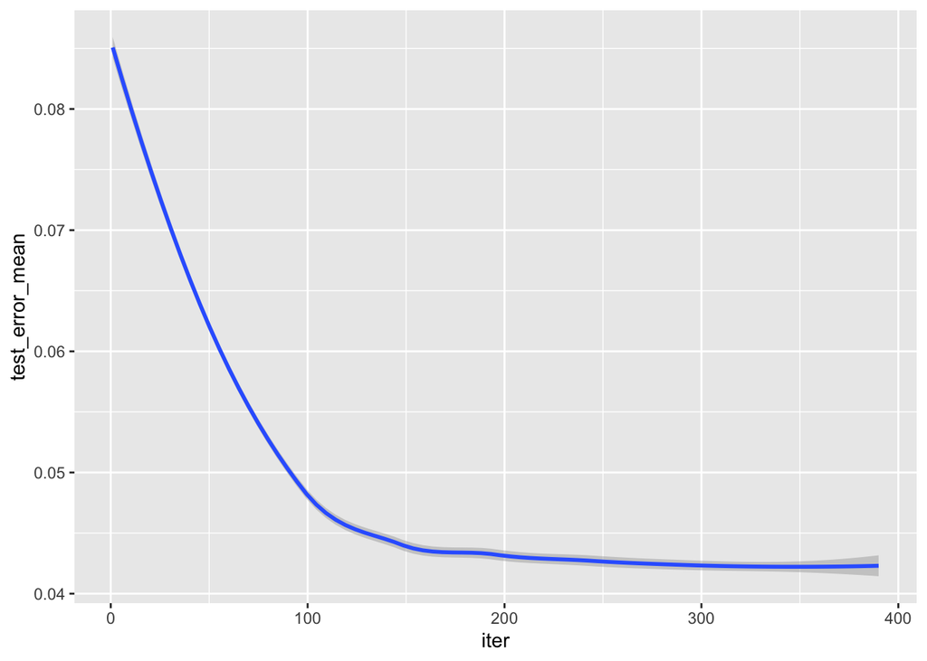

```r
ggplot(bst$evaluation_log, aes(x = iter, y=test_error_mean))+
  geom_smooth()
```

#Tune the eta parameter for XGboost

```r
set.seed(111111)
bst_mod_1 <- xgb.cv(data = dtrain, # Set training data

              nfold = 5, # Use 5 fold cross-validation

              eta = 0.3, # Set learning rate
              max.depth = 7, # Set max depth
              min_child_weight = 10, # Set minimum number of samples in node to split
              gamma = 0, # Set minimum loss reduction for split
              subsample = 0.9, # Set proportion of training data to use in tree
              colsample_bytree =  0.9, # Set number of variables to use in each tree

              nrounds = 500, # Set number of rounds
              early_stopping_rounds = 20,

              verbose = 1, # 1 - Prints out fit
              nthread = 1, # Set number of parallel threads
              print_every_n = 20, # Prints out result every 20th iteration

              objective = "binary:logistic", # Set objective
              eval_metric = "auc",
              eval_metric = "error")
```

```
## Multiple eval metrics are present. Will use test_error for early stopping.
## Will train until test_error hasn't improved in 20 rounds.
##
## Stopping. Best iteration:
```

```r
set.seed(111111)
bst_mod_2 <- xgb.cv(data = dtrain, # Set training data

              nfold = 5, # Use 5 fold cross-validation

              eta = 0.1, # Set learning rate
              max.depth =  7, # Set max depth
              min_child_weight = 10, # Set minimum number of samples in node to split
              gamma = 0, # Set minimum loss reduction for split
              subsample = 0.9 , # Set proportion of training data to use in tree
              colsample_bytree = 0.9, # Set number of variables to use in each tree

              nrounds = 500, # Set number of rounds
              early_stopping_rounds = 20, # Set number of rounds to stop at if there is no improvement

              verbose = 1, # 1 - Prints out fit
              nthread = 1, # Set number of parallel threads
              print_every_n = 20, # Prints out result every 20th iteration

              objective = "binary:logistic", # Set objective
              eval_metric = "auc",
              eval_metric = "error")
```

```
## Multiple eval metrics are present. Will use test_error for early stopping.
## Will train until test_error hasn't improved in 20 rounds.
##
## Stopping. Best iteration:
```

```r
set.seed(111111)
bst_mod_3 <- xgb.cv(data = dtrain, # Set training data

              nfold = 5, # Use 5 fold cross-validation

              eta = 0.05, # Set learning rate
              max.depth = 7, # Set max depth
              min_child_weight = 10 , # Set minimum number of samples in node to split
              gamma = 0, # Set minimum loss reduction for split
              subsample = 0.9 , # Set proportion of training data to use in tree
              colsample_bytree =  0.9, # Set number of variables to use in each tree

              nrounds = 500, # Set number of rounds
              early_stopping_rounds = 20, # Set number of rounds to stop at if there is no improvement

              verbose = 1, # 1 - Prints out fit
              nthread = 1, # Set number of parallel threads
              print_every_n = 20, # Prints out result every 20th iteration

              objective = "binary:logistic", # Set objective
              eval_metric = "auc",
              eval_metric = "error")
```

```
## Multiple eval metrics are present. Will use test_error for early stopping.
## Will train until test_error hasn't improved in 20 rounds.
##
## Stopping. Best iteration:
```

```r
set.seed(111111)
bst_mod_4 <- xgb.cv(data = dtrain, # Set training data

              nfold = 5, # Use 5 fold cross-validation

              eta = 0.01, # Set learning rate
              max.depth = 7, # Set max depth
              min_child_weight = 10, # Set minimum number of samples in node to split
              gamma = 0.1, # Set minimum loss reduction for split
              subsample = 0.9 , # Set proportion of training data to use in tree
              colsample_bytree = 0.9, # Set number of variables to use in each tree

              nrounds = 500, # Set number of rounds
              early_stopping_rounds = 20, # Set number of rounds to stop at if there is no improvement

              verbose = 1, # 1 - Prints out fit
              nthread = 1, # Set number of parallel threads
              print_every_n = 20, # Prints out result every 20th iteration

              objective = "binary:logistic", # Set objective
              eval_metric = "auc",
              eval_metric = "error")
```

```
## Multiple eval metrics are present. Will use test_error for early stopping.
## Will train until test_error hasn't improved in 20 rounds.
##
```

```r
set.seed(111111)
bst_mod_5 <- xgb.cv(data = dtrain, # Set training data

              nfold = 5, # Use 5 fold cross-validation

              eta = 0.005, # Set learning rate
              max.depth = 7, # Set max depth
              min_child_weight = 10, # Set minimum number of samples in node to split
              gamma = 0, # Set minimum loss reduction for split
              subsample = 0.9 , # Set proportion of training data to use in tree
              colsample_bytree = 0.9, # Set number of variables to use in each tree

              nrounds = 500, # Set number of rounds
              early_stopping_rounds = 20, # Set number of rounds to stop at if there is no improvement

              verbose = 1, # 1 - Prints out fit
              nthread = 1, # Set number of parallel threads
              print_every_n = 20, # Prints out result every 20th iteration

              objective = "binary:logistic", # Set objective
              eval_metric = "auc",
              eval_metric = "error")
```

```
## Multiple eval metrics are present. Will use test_error for early stopping.
## Will train until test_error hasn't improved in 20 rounds.
##
## Stopping. Best iteration:
```

```r
# Extract results for model with eta = 0.3
pd1 <- cbind.data.frame(bst_mod_1$evaluation_log[,c("iter", "test_error_mean")], rep(0.3, nrow(bst_mod_1$evaluation_log)))
names(pd1)[3] <- "eta"
# Extract results for model with eta = 0.1
pd2 <- cbind.data.frame(bst_mod_2$evaluation_log[,c("iter", "test_error_mean")], rep(0.1, nrow(bst_mod_2$evaluation_log)))
names(pd2)[3] <- "eta"
# Extract results for model with eta = 0.05
pd3 <- cbind.data.frame(bst_mod_3$evaluation_log[,c("iter", "test_error_mean")], rep(0.05, nrow(bst_mod_3$evaluation_log)))
names(pd3)[3] <- "eta"
# Extract results for model with eta = 0.01
pd4 <- cbind.data.frame(bst_mod_4$evaluation_log[,c("iter", "test_error_mean")], rep(0.01, nrow(bst_mod_4$evaluation_log)))
names(pd4)[3] <- "eta"
# Extract results for model with eta = 0.005
pd5 <- cbind.data.frame(bst_mod_5$evaluation_log[,c("iter", "test_error_mean")], rep(0.005, nrow(bst_mod_5$evaluation_log)))
names(pd5)[3] <- "eta"
# Join datasets
plot_data <- rbind.data.frame(pd1, pd2, pd3, pd4, pd5)
# Converty ETA to factor
plot_data$eta <- as.factor(plot_data$eta)
```

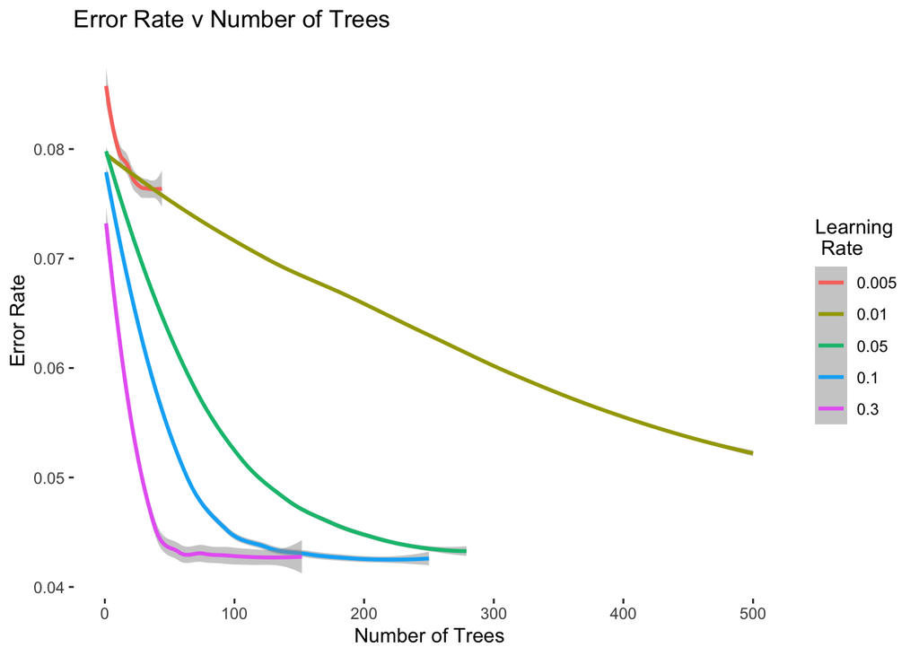

```r
g_7 <- ggplot(plot_data, aes(x = iter, y = test_error_mean, color = eta))+
  geom_smooth(alpha = 0.5) +
  theme_bw() + # Set theme
  theme(panel.grid.major = element_blank(), # Remove grid
        panel.grid.minor = element_blank(), # Remove grid
        panel.border = element_blank(), # Remove grid
        panel.background = element_blank()) + # Remove grid
  labs(x = "Number of Trees", title = "Error Rate v Number of Trees",
       y = "Error Rate", color = "Learning \n Rate")  # Set labels
g_7
```

From this it looks like an eta value of 0.3 gives the best results for this data set.

#Which features were most important for the Boost model?

```r
set.seed(111111)
bst_final <- xgboost(data = dtrain, # Set training data



              eta = 0.3, # Set learning rate
              max.depth =  7, # Set max depth
              min_child_weight = 10, # Set minimum number of samples in node to split
              gamma = 0, # Set minimum loss reduction for split
              subsample =  0.9, # Set proportion of training data to use in tree
              colsample_bytree = 0.9, # Set number of variables to use in each tree

              nrounds = 100, # Set number of rounds
              early_stopping_rounds = 20, # Set number of rounds to stop at if there is no improvement

              verbose = 1, # 1 - Prints out fit
              nthread = 1, # Set number of parallel threads
              print_every_n = 20, # Prints out result every 20th iteration

              objective = "binary:logistic", # Set objective
              eval_metric = "auc",
              eval_metric = "error")
```

```
## Multiple eval metrics are present. Will use train_error for early stopping.
## Will train until train_error hasn't improved in 20 rounds.
##
```

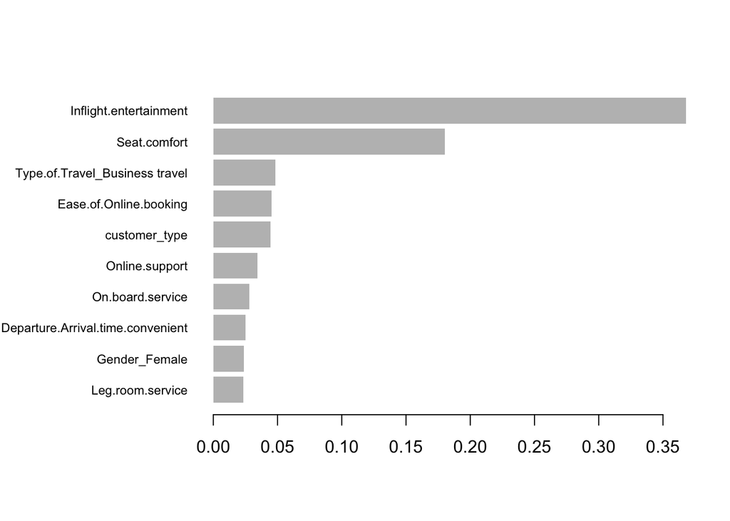

```r
# Extract importance
imp_mat <- xgb.importance(model = bst_final)
# Plot importance (top 10 variables)
xgb.plot.importance(imp_mat, top_n = 10)
```

#ROC plot

```r
boost_preds <- predict(bst_1, dtest)

roc2 = roc(test_dat$satisfied, boost_preds)
```

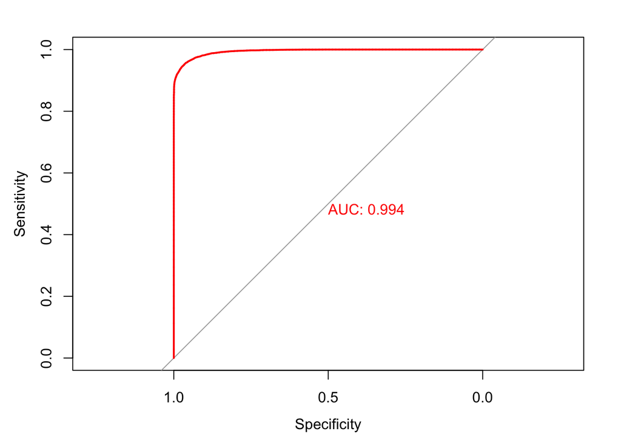

```r
plot.roc(roc2, print.auc = TRUE, col = "red", print.auc.col = "red")
```

The AUC for XG Boost is 0.994. AUC provides an aggregate measure of performance across all possible classification thresholds. One way of interpreting AUC is as the probability that the model ranks a random positive example more highly than a random negative example. AUC ranges in value from 0 to 1. A model whose predictions are 100% wrong has an AUC of 0.0; one whose predictions are 100% correct has an AUC of 1.0.

```r
boost_preds <- predict(bst_final, dtest) # Create predictions for random forest model

# Convert predictions to classes, using 0.5
boost_pred_class <- rep("1", length(boost_preds))
boost_pred_class[boost_preds >= 0.5] <- "2"

t <- table(boost_pred_class, test_dat$satisfied)
confusionMatrix(t, positive = "2")
```

```
## Confusion Matrix and Statistics
##
##
## boost_pred_class     1     2
##                1 11301   620
##                2   458 13597
##
##                Accuracy : 0.9585
##                  95% CI : (0.956, 0.9609)
##     No Information Rate : 0.5473
##     P-Value [Acc > NIR] : < 2.2e-16
##
##                   Kappa : 0.9164
##
##  Mcnemar's Test P-Value : 9.409e-07
##
##             Sensitivity : 0.9564
##             Specificity : 0.9611
##          Pos Pred Value : 0.9674
##          Neg Pred Value : 0.9480
##              Prevalence : 0.5473
##          Detection Rate : 0.5234
##    Detection Prevalence : 0.5411
##       Balanced Accuracy : 0.9587
##
##        'Positive' Class : 2
##
```

```r
summary(as.factor(train_dat$satisfied))
```

```
##     1     2
## 47034 56870
```

#### Loyalty as response

```r
# Create training matrix
dtrain2 <- xgb.DMatrix(data = as.matrix(train_dat[, c(1:26)]), label = as.numeric(train_dat$customer_type) - 1)
# Create test matrix
dtest2 <- xgb.DMatrix(data = as.matrix(test_dat[, c(1:26)]), label = as.numeric(test_dat$customer_type) -1 )
```

```r
set.seed(111111)
# Set training data
bst_2 <- xgboost(data = dtrain2, # Set training data

               nrounds = 100, # Set number of rounds

               verbose = 1, # 1 - Prints out fit
                print_every_n = 20, # Prints out result every 20th iteration

               objective = "binary:logistic", # Set objective
               eval_metric = "auc",
               eval_metric = "error")
```

```r
library(xgboost)
library(caret)
library(OptimalCutpoints) # Load optimal cutpoints
library(ggplot2) # Load ggplot2
library(xgboostExplainer) # Load XGboost Explainer
library(pROC)
library(SHAPforxgboost)

set.seed(111111)
bst <- xgb.cv(data = dtrain2, # Set training data

              nfold = 5, # Use 5 fold cross-validation

               eta = 0.1, # Set learning rate

               nrounds = 500, # Set number of rounds
               early_stopping_rounds = 50, # Set number of rounds to stop at if there is no improvement

               verbose = 1, # 1 - Prints out fit
               nthread = 1, # Set number of parallel threads
               print_every_n = 20, # Prints out result every 20th iteration

               objective = "binary:logistic", # Set objective
               eval_metric = "auc",
               eval_metric = "error") # Set evaluation metric to use
```

```
## Multiple eval metrics are present. Will use test_error for early stopping.
## Will train until test_error hasn't improved in 50 rounds.
##
```

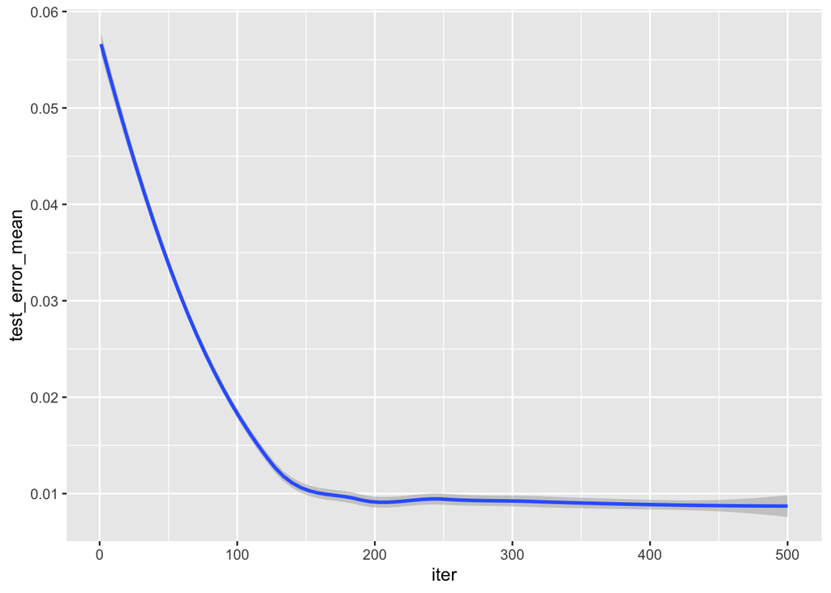

```r
ggplot(bst$evaluation_log, aes(x = iter, y=test_error_mean))+
  geom_smooth()
```

#Tune the eta parameter for XGboost

```r
set.seed(111111)
bst_mod_1 <- xgb.cv(data = dtrain2, # Set training data

              nfold = 5, # Use 5 fold cross-validation

              eta = 0.3, # Set learning rate
              max.depth = 7, # Set max depth
              min_child_weight = 10, # Set minimum number of samples in node to split
              gamma = 0, # Set minimum loss reduction for split
              subsample = 0.9, # Set proportion of training data to use in tree
              colsample_bytree =  0.9, # Set number of variables to use in each tree

              nrounds = 500, # Set number of rounds
              early_stopping_rounds = 20,

              verbose = 1, # 1 - Prints out fit
              nthread = 1, # Set number of parallel threads
              print_every_n = 20, # Prints out result every 20th iteration

              objective = "binary:logistic", # Set objective
              eval_metric = "auc",
              eval_metric = "error")
```

```
## Multiple eval metrics are present. Will use test_error for early stopping.
## Will train until test_error hasn't improved in 20 rounds.
##
## Stopping. Best iteration:
```

```r
set.seed(111111)
bst_mod_2 <- xgb.cv(data = dtrain2, # Set training data

              nfold = 5, # Use 5 fold cross-validation

              eta = 0.1, # Set learning rate
              max.depth =  7, # Set max depth
              min_child_weight = 10, # Set minimum number of samples in node to split
              gamma = 0, # Set minimum loss reduction for split
              subsample = 0.9 , # Set proportion of training data to use in tree
              colsample_bytree = 0.9, # Set number of variables to use in each tree

              nrounds = 500, # Set number of rounds
              early_stopping_rounds = 20, # Set number of rounds to stop at if there is no improvement

              verbose = 1, # 1 - Prints out fit
              nthread = 1, # Set number of parallel threads
              print_every_n = 20, # Prints out result every 20th iteration

              objective = "binary:logistic", # Set objective
              eval_metric = "auc",
              eval_metric = "error")
```

```
## Multiple eval metrics are present. Will use test_error for early stopping.
## Will train until test_error hasn't improved in 20 rounds.
##
## Stopping. Best iteration:
```

```r
set.seed(111111)
bst_mod_3 <- xgb.cv(data = dtrain2, # Set training data

              nfold = 5, # Use 5 fold cross-validation

              eta = 0.05, # Set learning rate
              max.depth = 7, # Set max depth
              min_child_weight = 10 , # Set minimum number of samples in node to split
              gamma = 0, # Set minimum loss reduction for split
              subsample = 0.9 , # Set proportion of training data to use in tree
              colsample_bytree =  0.9, # Set number of variables to use in each tree

              nrounds = 500, # Set number of rounds
              early_stopping_rounds = 20, # Set number of rounds to stop at if there is no improvement

              verbose = 1, # 1 - Prints out fit
              nthread = 1, # Set number of parallel threads
              print_every_n = 20, # Prints out result every 20th iteration

              objective = "binary:logistic", # Set objective
              eval_metric = "auc",
              eval_metric = "error")
```

```
## Multiple eval metrics are present. Will use test_error for early stopping.
## Will train until test_error hasn't improved in 20 rounds.
##
## Stopping. Best iteration:
```

```r
set.seed(111111)
bst_mod_4 <- xgb.cv(data = dtrain2, # Set training data

              nfold = 5, # Use 5 fold cross-validation

              eta = 0.01, # Set learning rate
              max.depth = 7, # Set max depth
              min_child_weight = 10, # Set minimum number of samples in node to split
              gamma = 0.1, # Set minimum loss reduction for split
              subsample = 0.9 , # Set proportion of training data to use in tree
              colsample_bytree = 0.9, # Set number of variables to use in each tree

              nrounds = 500, # Set number of rounds
              early_stopping_rounds = 20, # Set number of rounds to stop at if there is no improvement

              verbose = 1, # 1 - Prints out fit
              nthread = 1, # Set number of parallel threads
              print_every_n = 20, # Prints out result every 20th iteration

              objective = "binary:logistic", # Set objective
              eval_metric = "auc",
              eval_metric = "error")
```

```
## Multiple eval metrics are present. Will use test_error for early stopping.
## Will train until test_error hasn't improved in 20 rounds.
##
```

```r
set.seed(111111)
bst_mod_5 <- xgb.cv(data = dtrain2, # Set training data

              nfold = 5, # Use 5 fold cross-validation

              eta = 0.005, # Set learning rate
              max.depth = 7, # Set max depth
              min_child_weight = 10, # Set minimum number of samples in node to split
              gamma = 0, # Set minimum loss reduction for split
              subsample = 0.9 , # Set proportion of training data to use in tree
              colsample_bytree = 0.9, # Set number of variables to use in each tree

              nrounds = 500, # Set number of rounds
              early_stopping_rounds = 20, # Set number of rounds to stop at if there is no improvement

              verbose = 1, # 1 - Prints out fit
              nthread = 1, # Set number of parallel threads
              print_every_n = 20, # Prints out result every 20th iteration

              objective = "binary:logistic", # Set objective
              eval_metric = "auc",
              eval_metric = "error")
```

```
## Multiple eval metrics are present. Will use test_error for early stopping.
## Will train until test_error hasn't improved in 20 rounds.
##
## Stopping. Best iteration:
```

```r
# Extract results for model with eta = 0.3
pd1 <- cbind.data.frame(bst_mod_1$evaluation_log[,c("iter", "test_error_mean")], rep(0.3, nrow(bst_mod_1$evaluation_log)))
names(pd1)[3] <- "eta"
# Extract results for model with eta = 0.1
pd2 <- cbind.data.frame(bst_mod_2$evaluation_log[,c("iter", "test_error_mean")], rep(0.1, nrow(bst_mod_2$evaluation_log)))
names(pd2)[3] <- "eta"
# Extract results for model with eta = 0.05
pd3 <- cbind.data.frame(bst_mod_3$evaluation_log[,c("iter", "test_error_mean")], rep(0.05, nrow(bst_mod_3$evaluation_log)))
names(pd3)[3] <- "eta"
# Extract results for model with eta = 0.01
pd4 <- cbind.data.frame(bst_mod_4$evaluation_log[,c("iter", "test_error_mean")], rep(0.01, nrow(bst_mod_4$evaluation_log)))
names(pd4)[3] <- "eta"
# Extract results for model with eta = 0.005
pd5 <- cbind.data.frame(bst_mod_5$evaluation_log[,c("iter", "test_error_mean")], rep(0.005, nrow(bst_mod_5$evaluation_log)))
names(pd5)[3] <- "eta"
# Join datasets
plot_data <- rbind.data.frame(pd1, pd2, pd3, pd4, pd5)
# Converty ETA to factor
plot_data$eta <- as.factor(plot_data$eta)
```

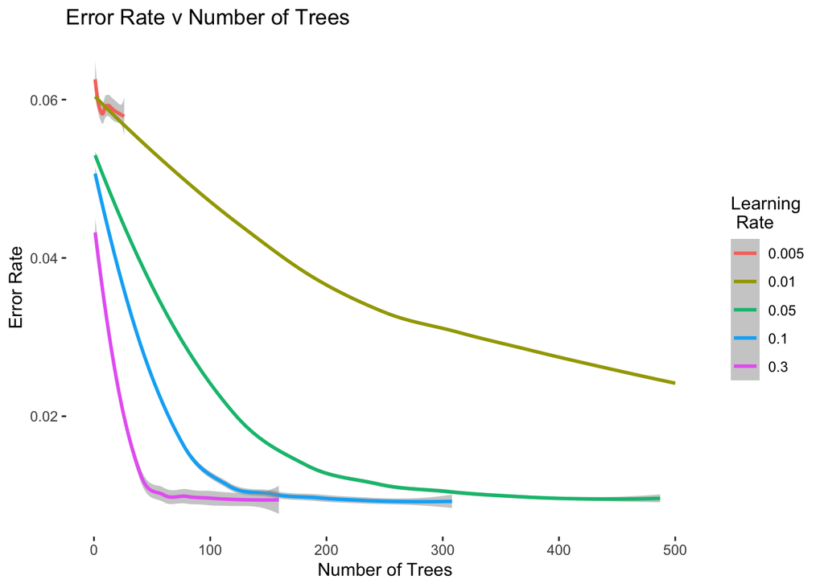

```r
g_7 <- ggplot(plot_data, aes(x = iter, y = test_error_mean, color = eta))+
  geom_smooth(alpha = 0.5) +
  theme_bw() + # Set theme
  theme(panel.grid.major = element_blank(), # Remove grid
        panel.grid.minor = element_blank(), # Remove grid
        panel.border = element_blank(), # Remove grid
        panel.background = element_blank()) + # Remove grid
  labs(x = "Number of Trees", title = "Error Rate v Number of Trees",
       y = "Error Rate", color = "Learning \n Rate")  # Set labels
g_7
```

From this it looks like an eta value of 0.3 gives the best results for this data set.

#Which features were most important for the Boost model?

```r
set.seed(111111)
bst_final <- xgboost(data = dtrain2, # Set training data



              eta = 0.3, # Set learning rate
              max.depth =  7, # Set max depth
              min_child_weight = 10, # Set minimum number of samples in node to split
              gamma = 0, # Set minimum loss reduction for split
              subsample =  0.9, # Set proportion of training data to use in tree
              colsample_bytree = 0.9, # Set number of variables to use in each tree

              nrounds = 100, # Set number of rounds
              early_stopping_rounds = 20, # Set number of rounds to stop at if there is no improvement

              verbose = 1, # 1 - Prints out fit
              nthread = 1, # Set number of parallel threads
              print_every_n = 20, # Prints out result every 20th iteration

              objective = "binary:logistic", # Set objective
              eval_metric = "auc",
              eval_metric = "error")
```

```
## Multiple eval metrics are present. Will use train_error for early stopping.
## Will train until train_error hasn't improved in 20 rounds.
##
```

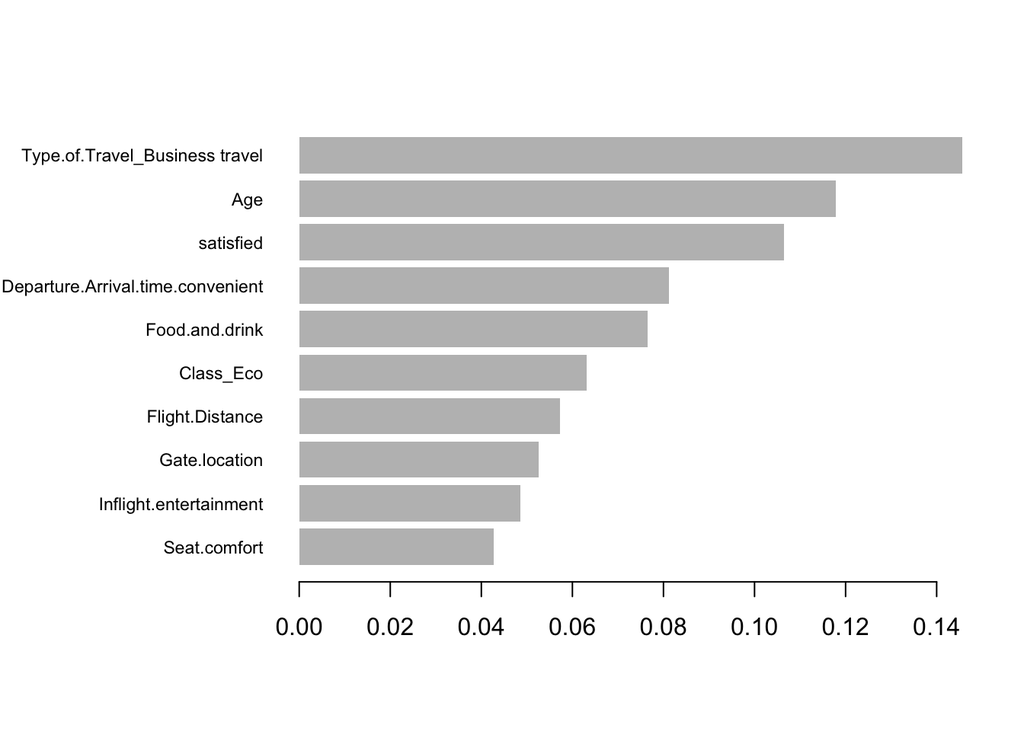

```r
# Extract importance
imp_mat <- xgb.importance(model = bst_final)
# Plot importance (top 10 variables)
xgb.plot.importance(imp_mat, top_n = 10)
```

Type.of.Travel_BusinessTravel and Age are most significant variables to predict loyalty.

#ROC plot

```r
boost_preds <- predict(bst_2, dtest2)

roc2 = roc(test_dat$customer_type, boost_preds)
```

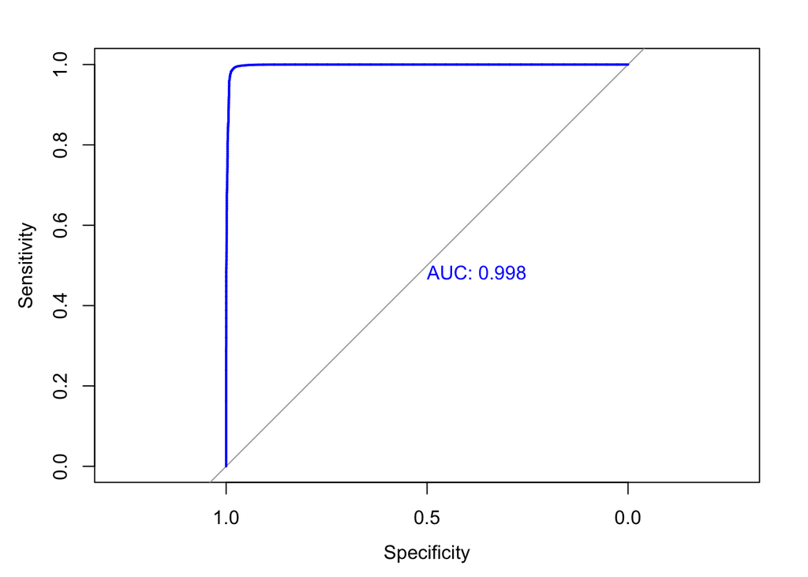

```r
plot.roc(roc2, print.auc = TRUE, col = "blue", print.auc.col = "blue")
```

AUC: 0.998 (Accuracy of model to predict customer loyalty)

```r
boost_preds <- predict(bst_final, dtest2) # Create predictions for random forest model

# Convert predictions to classes, using 0.5
boost_pred_class <- rep("1", length(boost_preds))
boost_pred_class[boost_preds >= 0.5] <- "2"

t <- table(boost_pred_class, test_dat$customer_type)
confusionMatrix(t, positive = "2")
```

```
## Confusion Matrix and Statistics
##
##
## boost_pred_class     1     2
##                1  4593    88
##                2   163 21132
##
##                Accuracy : 0.9903
##                  95% CI : (0.9891, 0.9915)
##     No Information Rate : 0.8169
##     P-Value [Acc > NIR] : <2e-16
##
##                   Kappa : 0.9675
##
##  Mcnemar's Test P-Value : 3e-06
##
##             Sensitivity : 0.9959
##             Specificity : 0.9657
##          Pos Pred Value : 0.9923
##          Neg Pred Value : 0.9812
##              Prevalence : 0.8169
##          Detection Rate : 0.8135
##    Detection Prevalence : 0.8198
##       Balanced Accuracy : 0.9808
##
##        'Positive' Class : 2
##
```

```r
summary(as.factor(train_dat$customer_type))
```

```
##     1     2
## 19024 84880
```

```r
zero_weight <- 19024/84880
```

```r
set.seed(111111)
bst_bal <- xgboost(data = dtrain2, # Set training data



              eta = 0.3, # Set learning rate
              max.depth =  7, # Set max depth
              min_child_weight = 10, # Set minimum number of samples in node to split
              gamma = 0, # Set minimum loss reduction for split
              subsample =  0.9, # Set proportion of training data to use in tree
              colsample_bytree = 0.9, # Set number of variables to use in each tree

              nrounds = 200, # Set number of rounds
              early_stopping_rounds = 20, # Set number of rounds to stop at if there is no improvement
              scale_pos_weight = zero_weight,
              verbose = 1, # 1 - Prints out fit
              nthread = 1, # Set number of parallel threads
              print_every_n = 20, # Prints out result every 20th iteration

              objective = "binary:logistic", # Set objective
              eval_metric = "auc",
              eval_metric = "error")
```

```
## Multiple eval metrics are present. Will use train_error for early stopping.
## Will train until train_error hasn't improved in 20 rounds.
##
```

```r
boost_preds_bal <- predict(bst_bal, dtest2) # Create predictions for XGBoost model

pred_dat <- cbind.data.frame(boost_preds_bal , test_dat$customer_type)
# Convert predictions to classes, using optimal cut-off
boost_pred_class <- rep("1", length(boost_preds_bal))
boost_pred_class[boost_preds_bal >= 0.5] <- "2"


t <- table(boost_pred_class, test_dat$satisfied) # Create table
confusionMatrix(t, positive = "2") # Produce confusion matrix
```

```
## Confusion Matrix and Statistics
##
##
## boost_pred_class     1     2
##                1  3680  1173
##                2  8079 13044
##
##                Accuracy : 0.6438
##                  95% CI : (0.638, 0.6497)
##     No Information Rate : 0.5473
##     P-Value [Acc > NIR] : < 2.2e-16
##
##                   Kappa : 0.2428
##
##  Mcnemar's Test P-Value : < 2.2e-16
##
##             Sensitivity : 0.9175
##             Specificity : 0.3130
##          Pos Pred Value : 0.6175
##          Neg Pred Value : 0.7583
##              Prevalence : 0.5473
##          Detection Rate : 0.5022
##    Detection Prevalence : 0.8132
##       Balanced Accuracy : 0.6152
##
##        'Positive' Class : 2
##
```

XG Boost End-